# Analysis of DNA methylation data

### 6. Calculate raw beta and M values and plot the densities of mean methylation values, dividing the samples in CTRL and DIS (suggestion: subset the beta and M values matrices in order to retain CTRL or DIS subjects and apply the function mean to the 2 subsets). Do you see any difference between the two groups?

The fluorescence intensity data is used to generate the methylation values. B and M values are metrics for quantifying methylation, derived directly from the fluorescence intensities measured by the methylation array: B-values quantify the proportion of DNA methylation at each CpG site, ranging from 0 (no methylation) to 1 (fully methylated). They are biologically intuitive and easy to interpret but tend to exhibit heteroscedasticity, particularly at the lower and upper extremes of the scale. M-values are calculated as the log2 ratio between methylated and unmethylated signal intensities. Unlike beta values, M-values are unbounded, spanning the entire real number line, and typically show homoscedasticity, which makes them statistically more robust for differential analysis. In this step, we computed the raw beta and M values using the functions getBeta() and getM(). We then calculated the mean methylation levels across all CpG sites separately for the two experimental groups — CTRL (wild type) and DIS (disease) — using the function apply() with MARGIN=1, which applies the calculation row-wise (i.e., across samples for each CpG site). The distributions of these mean values were estimated using the density() function, which performs kernel density estimation to approximate the continuous distribution of the data. For visualization, we used par(mfrow=c(1,2)) to split the plotting area into two side-by-side plots, allowing direct comparison between the beta and M value distributions. The first plot displays the density of mean beta values, with CTRL samples in blue (#0067E6) and DIS samples in red (#E50068). The second plot shows the same comparison for mean M values, following the same color scheme. The plotting functions plot() and lines() are used to create the density curves, while legend() places a key in the upper-right corner to indicate group identities. Biologically speaking, these density plots visualize the overall methylation states of the two groups. Methylation data typically exhibits a bimodal distribution, reflecting the fact that most CpG sites tend to be either highly methylated (beta close to 1) or largely unmethylated (beta close to 0), with fewer sites showing intermediate methylation levels. By comparing CTRL and disease groups, this plot helps to assess whether there are global shifts in methylation patterns, which could be indicative of disease-associated epigenetic alterations. Unfortunately, there doesn’t seem to be a noticible difference in the methylation patters of CTRL and DIS samples. There only seems to be a slight variation between CTRL and DIS Beta Values distribution, as the DIS curve shows lower peaks.

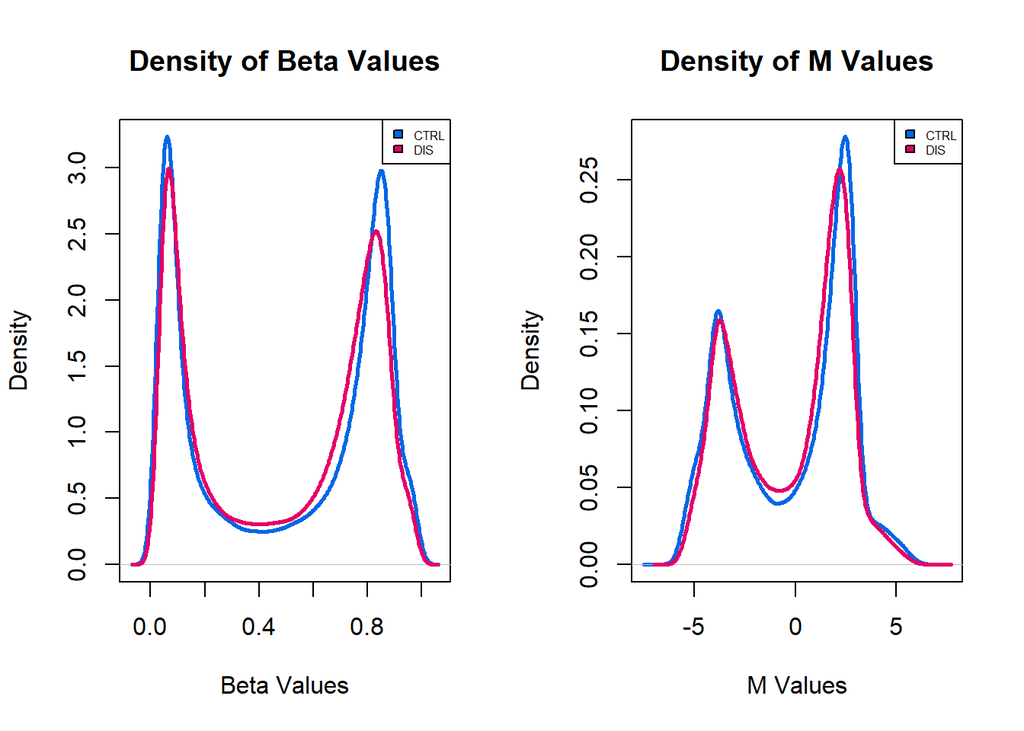

```r
#6a Calculate raw beta and M values and plot the densities of mean methylation values, dividing the samples in CTRL and DIS

beta <- getBeta(MSet.raw)
M <- getM(MSet.raw)

ctrl_raw<- basename(targets[targets$Group == "CTRL", "Basename"])
dis_raw<- basename(targets[targets$Group == "DIS", "Basename"])
ctrlSet <- MSet.raw[, colnames(MSet.raw) %in% ctrl_raw]
disSet <- MSet.raw[, colnames(MSet.raw) %in% dis_raw]
ctrlBeta <- getBeta(ctrlSet)
ctrlM <- getM(ctrlSet)
disBeta <- getBeta(disSet)
disM <- getM(disSet)
mean_ctrlBeta <- apply(ctrlBeta, MARGIN=1, mean, na.rm=TRUE)
mean_disBeta <- apply(disBeta, MARGIN=1, mean, na.rm=TRUE)
mean_ctrlM <- apply(ctrlM, MARGIN=1, mean, na.rm=TRUE)
mean_disM <- apply(disM, MARGIN=1, mean, na.rm=TRUE)
d_mean_ctrlBeta <- density(mean_ctrlBeta, na.rm=TRUE)
d_mean_disBeta <- density(mean_disBeta, na.rm=TRUE)
d_mean_ctrlM <- density(mean_ctrlM, na.rm=TRUE)
d_mean_disM <- density(mean_disM, na.rm=TRUE)

#6b Plot the density obtained in point 6a
# Plot density of mean Beta and M values
par(mfrow=c(1,2))  # Set up the plotting area to have 1 row and 2 columns
# Plot density of mean Beta values
plot(d_mean_ctrlBeta, main="Density of Beta Values", col="#0067E6", lwd=2.5, xlab="Beta Values", ylab="Density")
lines(d_mean_disBeta, col="#E50068", lwd=2.5)
legend('topright', legend=c("CTRL", "DIS"), fill=c("#0067E6", "#E50068"), cex=0.5)
# Plot density of mean M values
plot(d_mean_ctrlM, main="Density of M Values", col="#0067E6", lwd=2.5, xlab="M Values", ylab="Density")
lines(d_mean_disM, col="#E50068", lwd=2.5)
legend('topright', legend=c("CTRL", "DIS"), fill=c("#0067E6", "#E50068"), cex=0.5)
```

```r
# Reset plotting layout for subsequent plots
par(mfrow=c(1,1))
```

### 7. Normalize the data using the function assigned to each group and compare raw data and normalized data. Produce a plot with 6 panels in which, for both raw and normalized data, you show the density plots of beta mean values according to the chemistry of the probes, the density plot of beta standard deviation values according to the chemistry of the probes and the boxplot of beta values. Provide a short comment about the changes you observe. Optional: do you think that the normalization approach that you used is appropriate considering this specific dataset? Try to color the boxplots according to the group (WT and MUT) and check whether the distribution of methylation values is different between the two groups, before and after normalization

Our experimental goal is to identify biological variation, but technical variation can hide the real data. The aim of normalization methods is to remove unavoidable technical variation, in particular systematic bias. In order to increase the chance of identifying biological variation, normalisation is the starting point and the go to way. The easiest way to review the distribution is with box plot visualisation. Usually the values that we are interested in are the outliers, lower quartile values and median. Discussion of results using preprocessNoob; Let’s now consider the differences for each plot: Considering the Raw Beta Mean vs preprocessNoob Beta Mean we can see that the density curves show that type I and type II probes have different distributions in raw data while after applying the function preprocessNoob() differences are reduced. Considering Raw Beta SD vs preprocessNoob beta SD, we can see SD is diminished after normalisation, even if by a small amount. Considering the Boxpot normalisation, distributions after normalisation appear more similar, showing a good correction of batch effects. it is necessary to underlie that preprocessNoob is a function created for background correction, removing noise, and dye bias correction. Function like preprocessQuantile impose specific corrections for quantile distributions, that preprocessNoob doesn’t provide. Noob procedure is often suggested and has a greater effect considering M-values scales (Timothy et al., 2013)

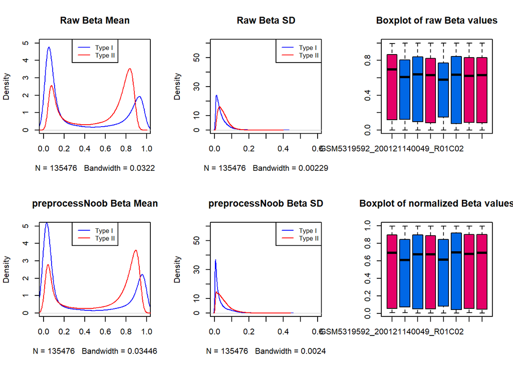

```r
# Subset the manifest into Type I (dfI) and Type II (dfII) probes based on Infinium_Design_Type
dfI <- Illumina450Manifest_clean[Illumina450Manifest_clean$Infinium_Design_Type == "I", ]
dfI <- droplevels(dfI)
dfII <- Illumina450Manifest_clean[Illumina450Manifest_clean$Infinium_Design_Type == "II", ]
dfII <- droplevels(dfII)

# Normalize using preprocessNoob
preprocessNoob_results <- preprocessNoob(RGset,dyeMethod="single")

# Separation of type I and type II probes.
beta_I <- beta[rownames(beta) %in% dfI$IlmnID, ]
beta_II <- beta[rownames(beta) %in% dfII$IlmnID, ]

# Calculate raw mean and sd
mean_of_beta_I <- apply(beta_I, 1, mean, na.rm = TRUE)
mean_of_beta_II <- apply(beta_II, 1, mean, na.rm = TRUE)
d_mean_of_beta_I <- density(mean_of_beta_I, na.rm = TRUE)
d_mean_of_beta_II <- density(mean_of_beta_II, na.rm = TRUE)
sd_of_beta_I <- apply(beta_I, 1, sd, na.rm = TRUE)
sd_of_beta_II <- apply(beta_II, 1, sd, na.rm = TRUE)
d_sd_of_beta_I <- density(sd_of_beta_I, na.rm = TRUE)
d_sd_of_beta_II <- density(sd_of_beta_II, na.rm = TRUE)

# Extract normalized beta values
beta_preprocessNoob <- getBeta(preprocessNoob_results)
beta_preprocessNoob_I <- beta_preprocessNoob[rownames(beta_preprocessNoob) %in% dfI$IlmnID, ]
beta_preprocessNoob_II <- beta_preprocessNoob[rownames(beta_preprocessNoob) %in% dfII$IlmnID, ]

# Calculate normalized mean and sd
mean_of_beta_preprocessNoob_I <- apply(beta_preprocessNoob_I, 1, mean, na.rm = TRUE)
mean_of_beta_preprocessNoob_II <- apply(beta_preprocessNoob_II, 1, mean, na.rm = TRUE)
d_mean_of_beta_preprocessNoob_I <- density(mean_of_beta_preprocessNoob_I, na.rm = TRUE)
d_mean_of_beta_preprocessNoob_II <- density(mean_of_beta_preprocessNoob_II, na.rm = TRUE)
sd_of_beta_preprocessNoob_I <- apply(beta_preprocessNoob_I, 1, sd, na.rm = TRUE)
sd_of_beta_preprocessNoob_II <- apply(beta_preprocessNoob_II, 1, sd, na.rm = TRUE)
d_sd_of_beta_preprocessNoob_I <- density(sd_of_beta_preprocessNoob_I, na.rm = TRUE)
d_sd_of_beta_preprocessNoob_II <- density(sd_of_beta_preprocessNoob_II, na.rm = TRUE)

# Set up the layout for the plots: 2 rows, 3 columns
par(mfrow = c(2, 3))

# Top Row: Raw Data
# Plot densities of mean beta values (raw)
plot(d_mean_of_beta_I, col = "blue", main = "Raw Beta Mean", xlim = c(0, 1), ylim = c(0, 5))
lines(d_mean_of_beta_II, col = "red")
legend("top", legend = c("Type I", "Type II"), col = c("blue", "red"), lty = 1, cex = 0.8)

# Plot densities of standard deviation beta values (raw)
plot(d_sd_of_beta_I, col = "blue", main = "Raw Beta SD", xlim = c(0, 0.6), ylim = c(0, 60))
lines(d_sd_of_beta_II, col = "red")
legend("topright", legend = c("Type I", "Type II"), col = c("blue", "red"), lty = 1, cex = 0.8)

# Boxplot of raw beta values
targets$Group <- as.factor(targets$Group)
palette(c("#E50068", "#0067E6"))
boxplot(beta, col = targets$Group)
title('Boxplot of raw Beta values')

# Bottom Row: Normalized Data
# Plot densities of mean beta values (preprocessNoob)
plot(d_mean_of_beta_preprocessNoob_I, col = "blue", main = "preprocessNoob Beta Mean", xlim = c(0, 1), ylim = c(0, 5))
lines(d_mean_of_beta_preprocessNoob_II, col = "red")
legend("top", legend = c("Type I", "Type II"), col = c("blue", "red"), lty = 1, cex = 0.8)

# Plot densities of standard deviation beta values (preprocessNoob)
plot(d_sd_of_beta_preprocessNoob_I, col = "blue", main = "preprocessNoob Beta SD", xlim = c(0, 0.6), ylim = c(0, 60))
lines(d_sd_of_beta_preprocessNoob_II, col = "red")
legend("topright", legend = c("Type I", "Type II"), col = c("blue", "red"), lty = 1, cex = 0.8)

# Boxplot of normalized beta values
boxplot(beta_preprocessNoob, col = targets$Group)
title('Boxplot of normalized Beta values')
```

```r
# Reset par settings to default (1 row, 1 column) to avoid affecting subsequent plots
par(mfrow = c(1, 1))
```

### 8. Perform a PCA on the matrix of normalized beta values generated in step 7. Comment the plot (Do you see any outlier? Do the samples divide according to the group? Do they divide according to the sex of the samples? Do they divide according to the batch, that is the column Sentrix_ID?).

```r
pca_results <- prcomp(t(beta_preprocessNoob), scale = TRUE)
install.packages("factoextra")
```

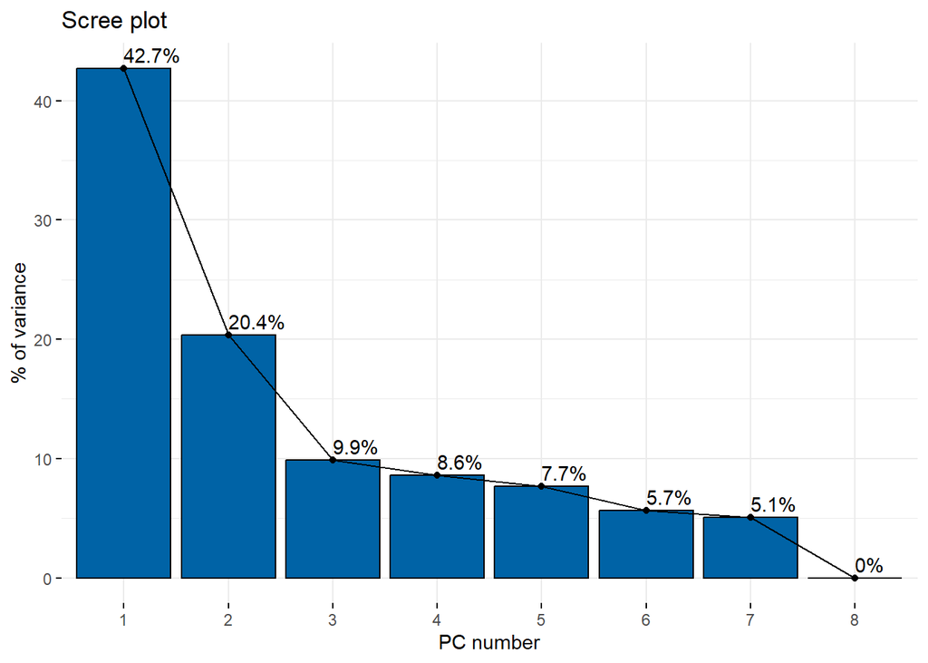

```r
library(factoextra)
fviz_eig(pca_results, addlabels = TRUE, xlab = 'PC number', ylab ='% of variance', barfill = "#0063A6", barcolor = "black")
```

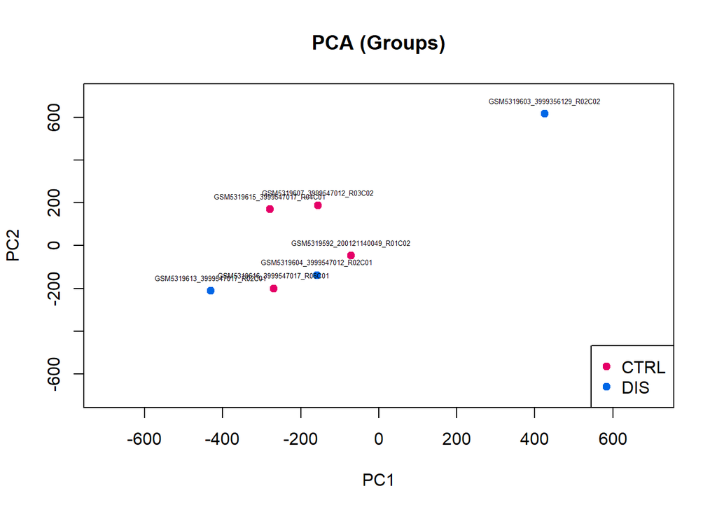

```r
# PCA plot per Group
targets$Group <- as.factor(targets$Group)
palette(c("#E50068", "#0067E6"))
plot(pca_results$x[, 1], pca_results$x[, 2], cex = 1, pch = 19, col = targets$Group, xlab = "PC1", ylab = "PC2", xlim = c(-700, 700), ylim = c(-700, 700), main = 'PCA (Groups)')
text(pca_results$x[, 1], pca_results$x[, 2], labels = rownames(pca_results$x), cex = 0.4, pos = 3)
legend("bottomright", legend = levels(targets$Group), col = c(1, 2), pch = 19, cex = 1.0)
```

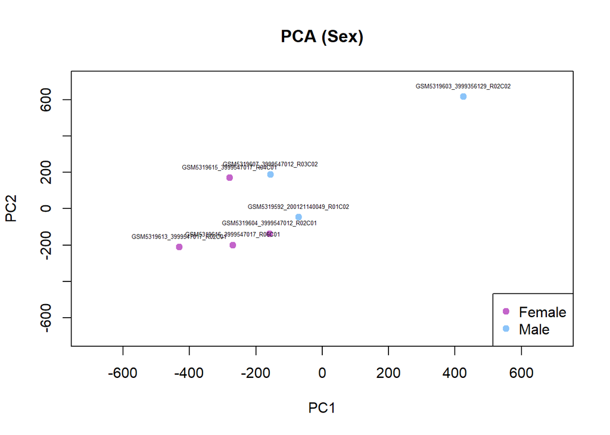

```r
# PCA plot per Sex
targets$Sex <- as.factor(targets$Sex)
palette(c("#C364CA", "#8BC4F9"))
plot(pca_results$x[, 1], pca_results$x[, 2], cex = 1, pch = 19, col = targets$Sex, xlab = "PC1", ylab = "PC2", xlim = c(-700, 700), ylim = c(-700, 700), main = 'PCA (Sex)')
text(pca_results$x[, 1], pca_results$x[, 2], labels = rownames(pca_results$x), cex = 0.4, pos = 3)
legend("bottomright", legend = levels(targets$Sex), col = c(1:nlevels(targets$Sex)), pch = 19, cex = 1.0)
```

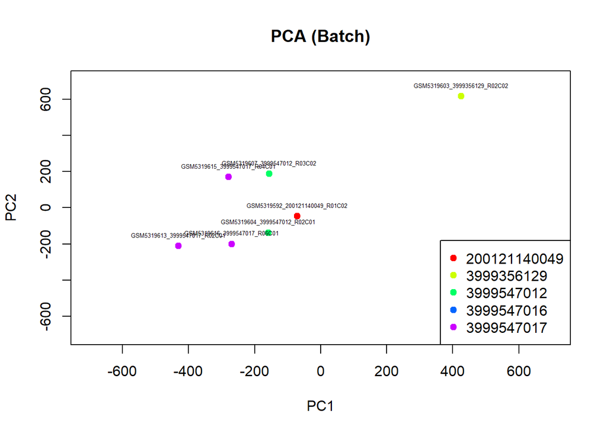

```r
# PCA plot colored by batch
targets$Slide <- as.factor(targets$Slide)
palette(rainbow(length(levels(targets$Slide))))
plot(pca_results$x[, 1], pca_results$x[, 2],
     cex = 1, pch = 19, col = as.numeric(targets$Slide),
     xlab = "PC1", ylab = "PC2",
     xlim = c(-700, 700), ylim = c(-700, 700),
     main = "PCA (Batch)")
text(pca_results$x[, 1], pca_results$x[, 2],
     labels = rownames(pca_results$x), cex = 0.4, pos = 3)
legend("bottomright",
       legend = levels(targets$Slide),
       col = 1:length(levels(targets$Slide)),
       pch = 19, cex = 1.0)
```

### 9. Using the matrix of normalized beta values generated in step 7, identify differentially methylated probes between CTRL and DIS groups using the function assigned to each group.

To assess the significance of a difference in methylation between the two probes is essential to perform a statistical validation procedure. Statistical tests that work on two groups can be divided into parametrical and non-parametrical tests. The Mann-Whitney U-test is a non-parametrical test and therefore is less powerful that parametrical ones. Also, considering the limited number of samples analysed (4 DIS and 4 CTRL) there is only a limited number of p-values that the test can assign to each probe, resulting in a lot of replicate p-values in the output of the test.

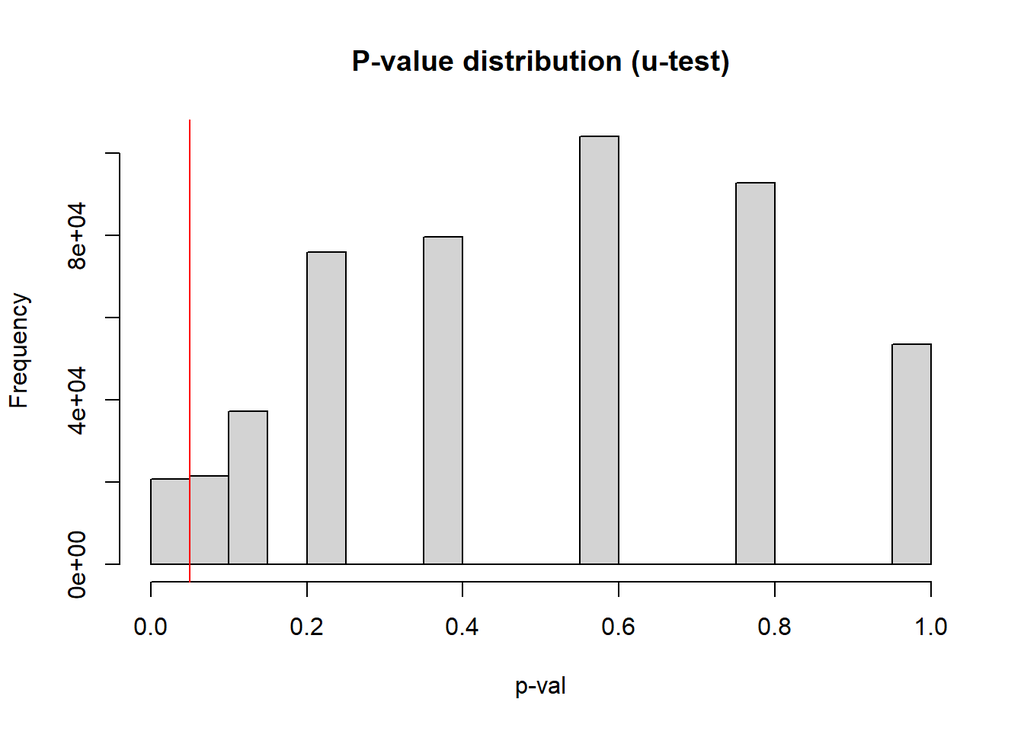

```r
pheno = SampleSheet
MannWhitney_function <- function(x) {
  u_test <- wilcox.test(x ~ pheno$Group, exact=FALSE, correct = FALSE)
  return(u_test$p.value)
}

#execute the function
pValues_u_test <- apply(beta_preprocessNoob,1, MannWhitney_function)
final_u_test <- data.frame(beta_preprocessNoob, pValues_u_test)

# Count the number of probes with a p-value <= 0.05
final_utest_th <- final_u_test[final_u_test$pValues_u_test <= 0.05, ]
hist(final_u_test$pValues_u_test, main = "P-value distribution (u-test)", xlab ='p-val')
abline(v = 0.05, col = "red")
```

```r
paste("Number of probes with a p-value ≤ 0.05: ",  dim(final_utest_th)[1])
```

```
## [1] "Number of probes with a p-value ≤ 0.05:  20798"
```

### 10. Apply multiple test correction and set a significant threshold of 0.05. How many probes do you identify as differentially methylated considering nominal pValues? How many after Bonferroni correction? How many after BH correction?

```r
corrected_pValues_BH <- p.adjust(final_u_test$pValues_u_test,"BH")
corrected_pValues_Bonf <- p.adjust(final_u_test$pValues_u_test,"bonferroni")

final_u_test_corrected <- data.frame(final_u_test, corrected_pValues_BH, corrected_pValues_Bonf)

#How many probes survive the multiple test correction?
dim(final_u_test[final_u_test$pValues_u_test<=0.05,])
```

```
## [1] 20798     9
```

```r
dim(final_u_test[final_u_test$corrected_pValues_BH<=0.05,])
```

```
## [1] 0 9
```

```r
dim(final_u_test_corrected[final_u_test_corrected$corrected_pValues_BH<=0.05,])
```

```
## [1]  0 11
```

```r
dim(final_u_test_corrected[final_u_test_corrected$corrected_pValues_Bonf<=0.05,])
```

```
## [1]  0 11
```

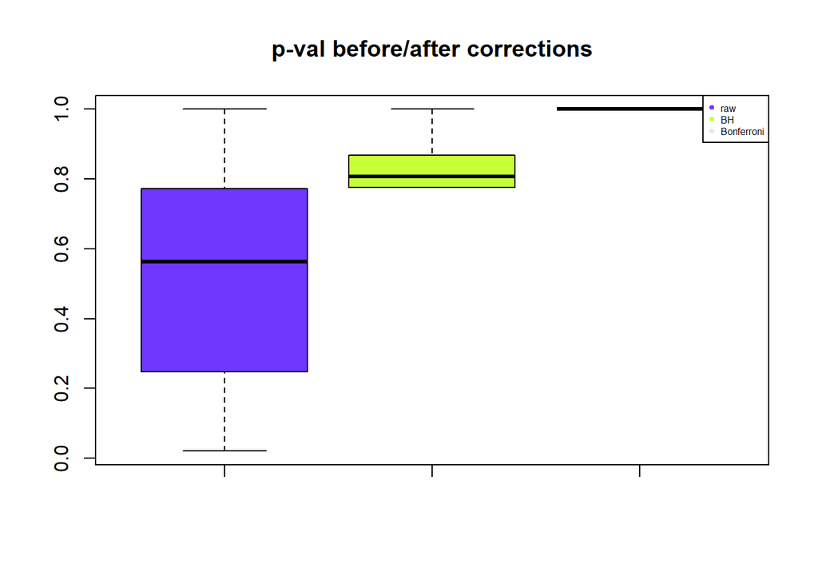

```r
# plotting
par(mfrow=c(1,1))
boxplot(final_u_test_corrected [,9:11], col = c("#7038FF", "#C7FF38", "seashell2"),names=NA, main='p-val before/after corrections')
legend("topright", legend=c("raw", "BH", "Bonferroni"),col=c("#7038FF", "#C7FF38", "seashell2"),pch=19, cex=0.5, xpd=TRUE)
```

### 11. Produce a volcano plot and a Manhattan plot of the results of differential methylation analysis

#### a. Volcano Plot

Each point in the plot corresponds to a specific CpG probe, for which the average methylation difference between the two groups has been calculated and is shown on the x-axis. In particular, the delta beta value indicates the average difference in methylation between the groups, with positive values suggesting higher methylation in the control group and negative values indicating increased methylation in the diseased group. The y-axis represents the statistical significance of each comparison, expressed as -log10(p-value), where p-value is obtained through the Mann-Whitney U test. This non-parametric test is suitable for comparing distributions between two independent groups and does not require assumptions of normality. In the plot, red points highlight CpG sites that meet two simultaneous criteria: a p-value lower than 0.05 and an absolute methylation difference equal to or greater than 10%. This filtering step ensures that only probes which are not only statistically significant but also biologically relevant in terms of methylation change are emphasized. Grey points, on the other hand, represent probes that fail to meet at least one of these criteria and are therefore considered non-significant. The data distribution shows a characteristic “stepped” pattern along the y-axis. This effect is consistent with the use of a non-parametric test such as the Mann-Whitney U, which, especially in datasets with limited size or discrete values, may produce repeated p-values, resulting in a visually segmented depiction of significance levels. Lastly, it is observed that the CpG sites with the greatest methylation differences between groups also tend to be those with higher negative log-transformed p-values, suggesting a consistency between the extent of epigenetic variation and its statistical significance.

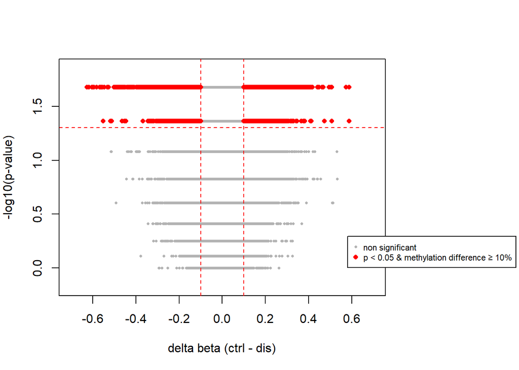

```r
volcano_u_test <- data.frame(beta_preprocessNoob, pValues_u_test)
beta_volcano <- volcano_u_test[,1:8]
beta_volcano_groupCTRL <- beta_volcano[,pheno$Group=="CTRL"]
mean_beta_volcano_groupCTRL <- apply(beta_volcano_groupCTRL,1,mean)
beta_volcano_groupDIS <- beta_volcano[,pheno$Group=="DIS"]
mean_beta_volcano_groupDIS <- apply(beta_volcano_groupDIS,1,mean)

#Now we can calculate the difference between average values:
delta_volcano <- mean_beta_volcano_groupCTRL-mean_beta_volcano_groupDIS

#Now we create a dataframe with two columns, one containing the delta values and the other with the -log10 of p-values
toVolcPlot_volcano <- data.frame(delta_volcano, -log10(volcano_u_test$pValues_u_test))

#This line is useful to format in a good way the graph to avoid overlap of the legend with our graph, hiding data.
par(mar = c(5, 4, 4, 9), xpd = TRUE)

#create Volcano Plot
plot(toVolcPlot_volcano[,1], toVolcPlot_volcano[,2],
     pch = 16, cex = 0.5, col = "grey70",
     xlab = "delta beta (ctrl - dis)", ylab = "-log10(p-value)",
     xlim = c(-0.7, 0.7),
     ylim = c(0, max(toVolcPlot_volcano[,2])),
     asp = 0.5)

#add significance line at p-value threshold 0.05
abline(h = -log10(0.05), col = "red", lty = 2, xpd = FALSE)

#add 10% differences in methylation line
abline(v = 0.1, col = "red", lty = 2, xpd = FALSE)
abline(v = -0.1, col = "red", lty = 2, xpd = FALSE)

# Highlight significant results
bh_sig <- toVolcPlot_volcano[
  volcano_u_test$pValues_u_test < 0.05 &
    abs(toVolcPlot_volcano[,1]) > 0.1, ]

points(bh_sig[,1], bh_sig[,2], pch = 16, cex = 0.8, col = "red")

# Legend
legend("bottomright",inset = c(-0.4, 0.12),
       legend = c("non significant",  "p < 0.05 & methylation difference ≥ 10%"),
       col = c("grey70", "red"),
       pch = 16, pt.cex = c(0.5, 0.8), cex = 0.7)
```

#### b. Manhattan Plot

The Manhattan plot was generated based on the p-values obtained from the Mann-Whitney U statistical test. For each CpG probe, chromosomal information (chromosome number and genomic position) was retrieved and associated with the corresponding statistical significance value. The adopted significance threshold was set at p-value < 0.05, consistent with the threshold used in the volcano plot, and is represented as an horizontal reference line in the graph. However, the resulting visualization does not display clearly defined peaks or continuous gradients of significance, but rather a distribution across discrete horizontal levels. This behavior reflects an intrinsic characteristic of the Mann-Whitney test which, in the presence of a limited number of samples per group (in this case, 8 per CpG site), returns a restricted set of distinct p-values. As a result, the points in the Manhattan plot tend to align along a few levels of significance, producing a “banded” visual effect rather than a continuous one. Despite having a limited impact in terms of visual immediacy, the plot accurately represents the genomic distribution of the tested probes and provides a concise overview of their statistical significance along the chromosomes. For major clarity, given that displaying all the significant probe names directly on the plot would be overly complex and visually unclear, the script was designed to export a .csv file (“significantly_probes.csv”) listing all probes that exceed the adopted significance threshold (p-value < 0.05). For each probe, the file includes its identifier, ordered by chromosome from 1 to 24 (where 23 = X and 24 = Y), and the p-value obtained through the Mann-Whitney U test. This output could serves as a useful resource for further analyses on significantly variable CpG sites per chromosome.

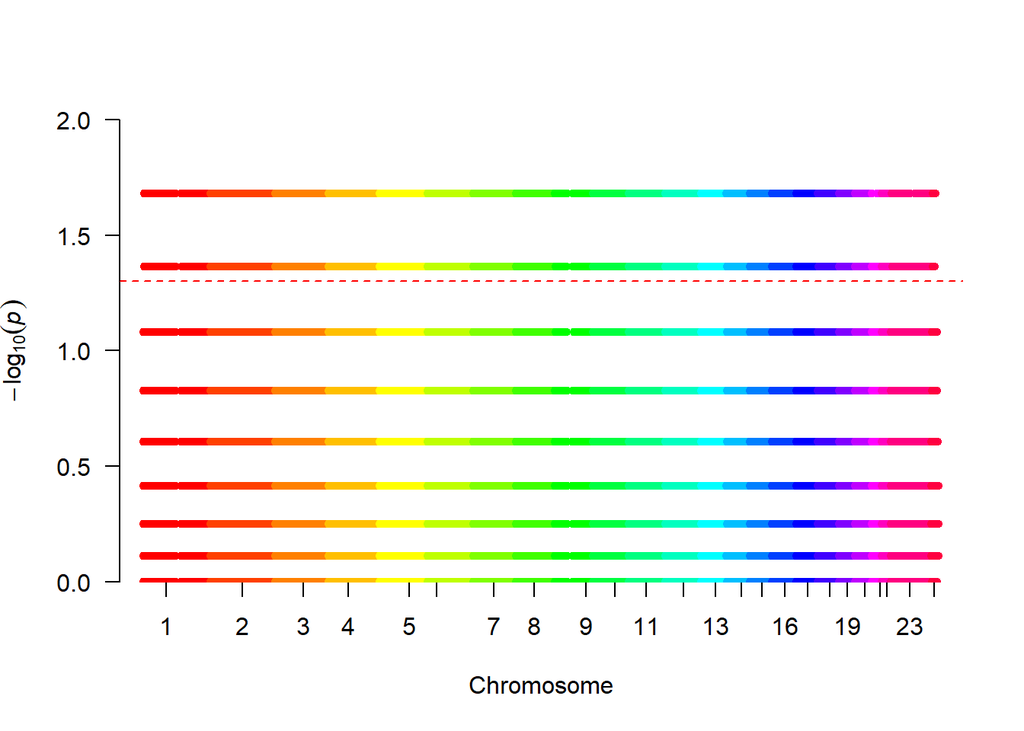

```r
install.packages("qqman")
library(qqman)

#We prepare the annotation of the p-value per probe, recovering CHR, MAPINFO, IlmnID
final_u_test_manhattan <- data.frame(rownames(volcano_u_test),volcano_u_test)
colnames(final_u_test_manhattan)[1] <- "IlmnID"

final_u_test_manhattan_annotated <- merge(final_u_test_manhattan, Illumina450Manifest_clean,by="IlmnID")


# Now we can create the input for the Manhattan plot analysis. The input object should contain 4 info: probe, chromosome, position on the chromosome and p-value. We will select these columns in the final_u_test_manhattan_annotated object
input_Manhattan <- final_u_test_manhattan_annotated[colnames(final_u_test_manhattan_annotated) %in% c("IlmnID","CHR","MAPINFO","pValues_u_test")]

# It is better to reorder the levels of the CHR
order_chr <- c("1","2","3","4","5","6","7","8","9","10","11","12","13","14","15","16","17","18","19","20","21","22","X","Y")
input_Manhattan$CHR <- factor(input_Manhattan$CHR,levels=order_chr )



# the column "CHR" should be numeric --> we will convert factors to numbers
input_Manhattan$CHR <- as.numeric(input_Manhattan$CHR)

# and finally we can produce our Manhattan plot
par(xaxs = "i")
manhattan(input_Manhattan, snp="IlmnID",chr="CHR", bp="MAPINFO", p="pValues_u_test",col=rainbow(24) )
abline(h = -log10(0.05), col = "red", lty = 2)
```

```r
# Extract the ids, chromosome and Mann-Whitney U test p-values of each probes with p-value above the threshold
significantly_probes <- input_Manhattan[input_Manhattan$pValues_u_test < 0.05, ]
#reorder these ids per chromosomes and insert them into the file.csv useful for possible further analysis
probes_table <- significantly_probes[, c("IlmnID", "pValues_u_test","CHR")]
probes_table <- probes_table[order(probes_table$CHR), ]
write.csv(probes_table, "significantly_probes.csv", row.names = FALSE)
```

### 12. Produce an heatmap of the top 100 significant, differentially methylated probes.

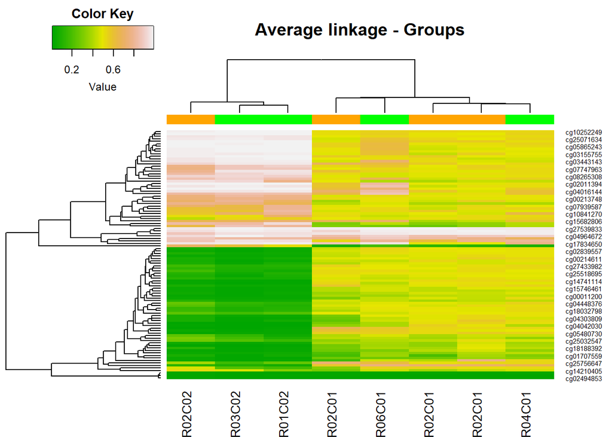

```r
install.packages("gplots")
library(gplots)

# It wants as input a matrix. As an heatmap on several thousands of probes is computationally demanding, for our analysis we will use just the top 100 most significant CpG probes. We will extract only beta values for these top 100 probes and convert them in a matrix:
input_heatmap=as.matrix(volcano_u_test[1:100,1:8])


# Finally, we we create a bar of colors for Group A or Group B membership
colorbar_group <- c("green","orange","orange","green","orange","orange","green","green")


# We used average linkage mapping to find the distance relation between clusters
heatmap.2(input_heatmap,col=terrain.colors(100),Rowv=T,Colv=T,hclustfun = function(x) hclust(x,method = 'average'),dendrogram="both",key=T,ColSideColors=colorbar_group,density.info="none",trace="none",scale="none",symm=F,main="Average linkage - Groups")
```

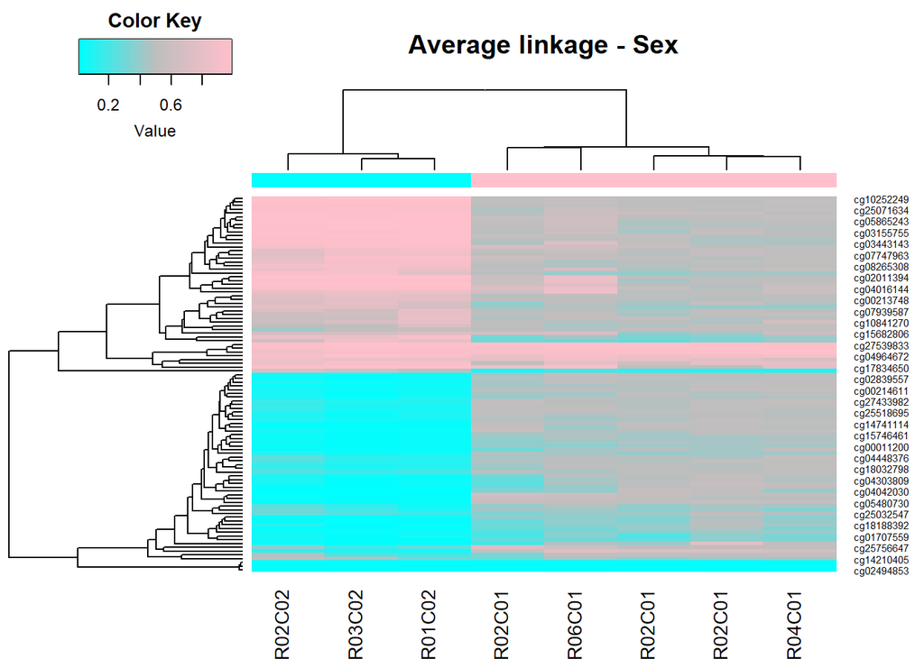

```r
#We performed also the analysis comparing sample using sex groups
colorbar_sex <- c("cyan","cyan","pink","cyan","pink","pink","pink","pink")


# Average
heatmap.2(input_heatmap,col=colorRampPalette(c("cyan","grey","pink"))(100),Rowv=T,Colv=T,hclustfun = function(x) hclust(x,method = 'average'),dendrogram="both",key=T,ColSideColors=colorbar_sex,density.info="none",trace="none",scale="none",symm=F,main="Average linkage - Sex")
```